# Examples of using pandas

## Loading datasets

First we load a Stata (https://en.wikipedia.org/wiki/Stata) proprietary data file. Paquete estadisco es stata, y los ficheros tienen la extension dta.

```python
import pandas as pd
data1 = pd.read_stata("dats.dta")
print data1.size
data1.head()
```

```
1428
```

|  | idpatient | entryear | sex | infection |
| --- | --- | --- | --- | --- |
| 0 | 1.0 | 1995.0 | Male | HCV+ & HIV- |
| 1 | 2.0 | 1995.0 | Male | HCV+ & HIV- |
| 2 | 3.0 | 1995.0 | Male | HCV+ & HIV- |
| 3 | 4.0 | 1995.0 | Male | HCV+ & HIV- |
| 4 | 5.0 | 1995.0 | Male | HCV+ & HIV- |

Let's find out the values in "infection". MIrar cuales son los distintos valores que puede tomar la columna.( con unique)

```python
data1["infection"].unique()
```

```
[HCV+ & HIV-, HCV+ & HIV+]
Categories (2, object): [HCV+ & HIV- < HCV+ & HIV+]
```

```python
data1["entryear"].unique()
```

```
array([ 1995.,  1996.,  1997.,  1998.,  1999.,  2000.,  2001.,  2002.,
        2003.])
```

Now let's see the distribution of years and sex. Agrupamos: con groupby. Es como si hicieramos varios grupos sobre el dataframe. Con el Count me cuenta los valores de cada fila por cada uno de los grupos.

```python
byyear = data1.groupby("entryear")
print byyear.count()
```

```
          idpatient  sex  infection
entryear
1995.0           53   53         53
1996.0           60   60         60
1997.0           63   63         63
1998.0           43   43         43
1999.0           48   48         48
2000.0           30   30         30
2001.0           19   19         19
2002.0           25   25         25
2003.0           16   16         16
```

El byyear es es una especie de indice, es decir que si trabajamos sobre byyear y modificamos los datos, se mofican los del dataframe original.

```python
some_part = data1[data1["entryear"]>2000]
print some_part.groupby("entryear").count()
```

```
          idpatient  sex  infection
entryear
2001.0           19   19         19
2002.0           25   25         25
2003.0           16   16         16
```

```python
data1.groupby("sex").count()
```

| sex | idpatient | entryear | infection |
| --- | --- | --- | --- |
| Male | 290 | 290 | 290 |
| Female | 67 | 67 | 67 |

## Merging datasets

Esto es como el Join en SQL.

Now we have a second dataset with more data.

```python
data2 = pd.read_csv("TxtDatafile.txt")
data2.head()
```

|  | idpatient entryear sex infection timeaddic |
| --- | --- |
| 0 | 54\t1996\tFemale\tHCV+ & HIV-\t168 |
| 1 | 55\t1996\tFemale\tHCV+ & HIV-\t96 |
| 2 | 56\t1996\tFemale\tHCV+ & HIV-\t108 |
| 3 | 57\t1996\tFemale\tHCV+ & HIV-\t60 |
| 4 | 58\t1996\tFemale\tHCV+ & HIV-\t96 |

It seems the data was no CSV(Look at the \t characters)

```python
data2 = pd.read_table("TxtDatafile.txt")
print data2.size
data2.head()
```

```
1550
```

|  | idpatient | entryear | sex | infection | timeaddic |
| --- | --- | --- | --- | --- | --- |
| 0 | 54 | 1996 | Female | HCV+ & HIV- | 168 |
| 1 | 55 | 1996 | Female | HCV+ & HIV- | 96 |
| 2 | 56 | 1996 | Female | HCV+ & HIV- | 108 |
| 3 | 57 | 1996 | Female | HCV+ & HIV- | 60 |
| 4 | 58 | 1996 | Female | HCV+ & HIV- | 96 |

Merge es el Join entre dos tablas. Con how le decimos el comportamiento. Outer, quiere decir, que la tabla resultante meta todos los datos, con que este en una de ellas basta, y tambien se puede poner left o right, que incluya los que esten una tabla o la otra. Y la innerjoin, es los que incluya solo los que estan los dos.

```python
data = data1.merge(data2, how="outer")
print data.size
data.head()
```

```
1815
```

|  | idpatient | entryear | sex | infection | timeaddic |
| --- | --- | --- | --- | --- | --- |
| 0 | 1.0 | 1995.0 | Male | HCV+ & HIV- | NaN |
| 1 | 2.0 | 1995.0 | Male | HCV+ & HIV- | NaN |
| 2 | 3.0 | 1995.0 | Male | HCV+ & HIV- | NaN |
| 3 | 4.0 | 1995.0 | Male | HCV+ & HIV- | NaN |
| 4 | 5.0 | 1995.0 | Male | HCV+ & HIV- | NaN |

```python
missingtime = data[pd.isnull(data["timeaddic"])]
missingtime.size
```

```
265
```

We can then drop rows that contain any NA values, this is the default behaviour of dropna() Si hay un nulo, que hacemos? esta es la decicion a tomar... en este caso, lo vamos a eliminar. Con la funcion dropna, que se carga todas las columnas que hay NA y se los carga... hay parametros para esto.

```python
data = data.dropna()
print data.size
data.head()
```

```
1550
```

|  | idpatient | entryear | sex | infection | timeaddic |
| --- | --- | --- | --- | --- | --- |
| 53 | 54.0 | 1996.0 | Female | HCV+ & HIV- | 168.0 |
| 54 | 55.0 | 1996.0 | Female | HCV+ & HIV- | 96.0 |
| 55 | 56.0 | 1996.0 | Female | HCV+ & HIV- | 108.0 |
| 56 | 57.0 | 1996.0 | Female | HCV+ & HIV- | 60.0 |
| 57 | 58.0 | 1996.0 | Female | HCV+ & HIV- | 96.0 |

## Visualizing via pandas

Pandas incorporates some methods to create plots using matplotlib behind the scenes. We can plot the whole dataframe, but in this case it will be nonsensical.

Se pintan los datos, pero no tienen sentido.

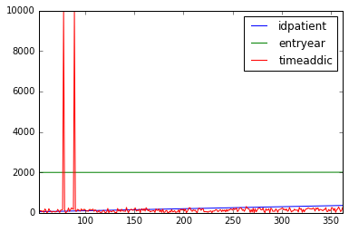

```python
%matplotlib inline
data.plot()
```

con subplot=true, ya le indicamos que tiene que hacer tres graficos distintos.

[output not shown]

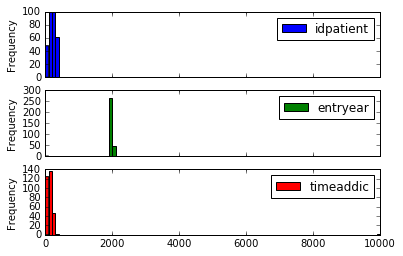

```python
data.plot(subplots=True, kind="hist", bins=100)
```

As we see, unless the data is in similar ranges it makes sense to plot it individually.

ahora, le indicamos solo la columna de timeadicc.

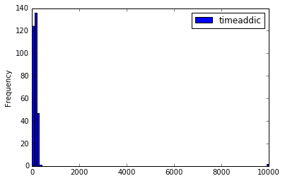

```python
data.plot(y="timeaddic", kind="hist", bins=100)
```

```python
# The maximum value:
print data["timeaddic"].max()
# And the position of that value:
print data["timeaddic"].argmax()
data.ix[78]
```

```
9999.0
78
```

```
idpatient             79
entryear            1996
sex                 Male
infection    HCV+ & HIV-
timeaddic           9999
Name: 78, dtype: object
```

Then we can exclude that value from the visualization. Para excluir el valor, lo filtramos.

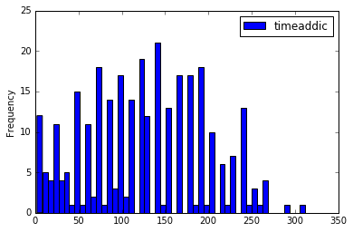

```python
dataclean = data[data["timeaddic"]<9999]
dataclean.plot(y="timeaddic", kind="hist", bins=50)
```

## Using subsets

The grouping in pandas allows for studying different sub-samples easily. Saber si ser adicto influye en tener el VIH. se utiliza un groupby por infeccion, hacemos un boxplot para ver la media, etc.. lo aplica cada grupo.

[output not shown]

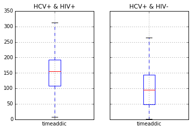

```python
bydisease = dataclean.groupby("infection")
bydisease.boxplot(column="timeaddic")
```

una funcion ttest_ind para evaluar dos arrays ( trabaja con Numpay). bydisease.groups.values() esto da las series de datos y se meten en la funcion.

Let's check if the mean of both subpopulations is the same.

```python
from scipy.stats import ttest_ind
g1, g2 = bydisease.groups.values()
ts, p = ttest_ind(g1, g2)
print p
print 'Difference!' if p < 0.05 else 'No difference'
```

```
0.00200590028439
Difference!
```

From the doc of ttest_ind: If the p-value is smaller than the threshold, e.g. 1%, 5% or 10%, then we reject the null hypothesis of equal averages.

We can also use categorical variables to create multiplots.

[output not shown]

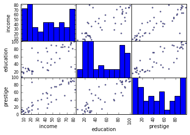

```python
from pandas.tools.plotting import scatter_matrix
import statsmodels.api as sm

duncan_prestige = sm.datasets.get_rdataset("Duncan", "car").data

# print duncan_prestige.__doc__

scatter_matrix(duncan_prestige)
```

## A glimpse to statmodels

In statistical libraries and machine learning, data can be specified via formulas or via selection of columns.

More info at: http://statsmodels.sourceforge.net/documentation.html

```python
import statsmodels.formula.api as smf
import statsmodels.api as sm
# Get a dataset from R collection:
df = sm.datasets.get_rdataset("Guerry", "HistData").data
# Select some fields:
df = df[['Lottery', 'Literacy', 'Wealth', 'Region']].dropna()
df.head()
```

|  | Lottery | Literacy | Wealth | Region |
| --- | --- | --- | --- | --- |
| 0 | 41 | 37 | 73 | E |
| 1 | 38 | 51 | 22 | N |
| 2 | 66 | 13 | 61 | C |
| 3 | 80 | 46 | 76 | E |
| 4 | 79 | 69 | 83 | E |

```python
mod = smf.ols(formula='Lottery ~ Literacy + Wealth', data=df)
res = mod.fit()
print res.params
print res.rsquared
```

```
Intercept    39.797879
Literacy     -0.378007
Wealth        0.413826
dtype: float64
0.308778740779
```

```python
y = df['Lottery']
X = df[['Literacy', 'Wealth']]
mod2 = sm.OLS(y,X)
res = mod2.fit()
print res.params
print res.rsquared
```

```
Literacy    0.181394
Wealth      0.749521
dtype: float64
0.776785535712
```